# Enchantillonage préférentiel

**Omar El Mellouki & Bertrand PATUREL**

**Professeur : Pierre GLOAGUEN**

Cours ENSTA : https://papayoun.github.io/courses/2020_monte_carlo/

Dans ce problème nous étudions la probabilité qu'un joueur gagne le jackpot lors d'un jeu de hasard à espérance $\mu$ négative. Ce joueur s'arrete si il est ruiné (noté $ r<0 $) ou bien si la somme de ses gains dépasse le jackpot (noté $j > 0$). Si l'on note $X_n$ la variable aléatoire de ce que le joueur remporte à chaque fois qu'il joue, alors $S_n=\sum_{k=1}^nX_k$ est la somme de ses gains. Nous notons $\tau$ le temps d'arret (i.e. le dernier coup du joueur) qui vérifie $S_{\tau}\leq r ou S_{\tau}\geq j$.

## Introduction :

Nous allons simuler une marche aléatoire à n pas avec condition d'arrêt dans le but d'étudier le problème de la ruine du joueur dans un jeu à espérance négative qui décide de s'arrêter quand il est ruiné ou quand il gagne le jackpot. Pour cela l'on va simuler la réalisations de variables aléatoires i.i.d gaussienne à moyenne négative et de variance 1, puis l'on va calculer la somme de ces valeurs propres *tant que* le joueur n'est pas ruiné ou qu'il n'a pas gagné le jackpot.

## Calcul de l'estimateur de Monte Carlo de la probabilité que le joueur gagne.

On note $p∗=\mathbb{P}(S_{\tau}≥j)$, avec $\tau$ représentant le temps d'arrêt et j le jackpot. $p∗$ est donc la probabilité de gagner le jackpot.

Afin de calculer la probabilité par la méthode de Monte-Carlo, on l'exprime sous la forme de l'espérance d'une indicatrice.

On a alors $p∗=\mathbb{E}(\mathbb{1}_{S_\tau \geq j})$

Un estimateur de Monte-Carlo serait $\hat{p}=\frac{1}{M}\sum_{k=1}^{M}\mathbb{1}_{S_\tau(k) \geq j}$

## Implémentation de l'estimateur de Monte Carlo en R.

4e-05

4e-05

3.99987999879998e-05

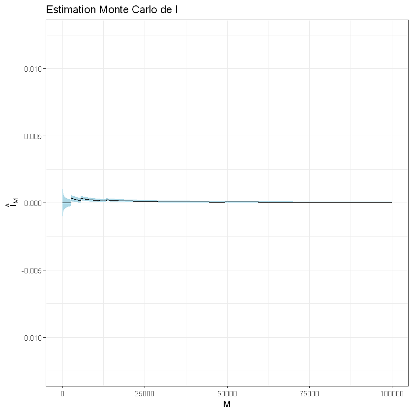

```r
mu = 1
r = -50
j = 5
M = 100000

#Simulation d'une trajectoire
S_t = 0
while((S_t<j) & (S_t>r)){
  X = rnorm(1,-mu,1)
  S_t = S_t + X
}

# La fonction indicatrice
indicatrice = function(vec,A)#On créée la fonction indicatrice ou A est le palier à dépasser
{
  n=length(vec)
  value = rep(x=0,n)
  for(i in 1:n)
  {
    if(vec[i]>=A){value[i] = 1}
  }
  return(value)
}

#Le vecteur des phi
phi = c(1:M)

for(i in 1:M){
  S_t = 0
  while((S_t<j) & (S_t>r)){
    X = rnorm(1,-mu,1)
    S_t = S_t + X
  }
  phi[i] = indicatrice(S_t,j)
}

#L'estimateur de Monte Carlo
p_star = mean(phi)
p_star

I_hat <- mean(phi) # Estimateur de Monte Carlo de la proba
gamma2_hat <- var(phi) # Variance de Monte Carlo de la proba
z_975 <- qnorm(0.975, 0, 1) # Quantile à 0.975 de la loi normale centrée réduite
IC = I_hat + z_975 * sqrt(gamma2_hat / M) * c(-1, 1) #Intervalle de confiance


### On affiche finalement l'intervalle de confiance à 95 %
library(ggplot2)
library(dplyr)

my_samples = tibble(index = 1:M, sample = phi)
my_samples %>%
  mutate(Estimate = cumsum(sample) / index,
         IC_95_inf = Estimate - z_975 * sqrt(gamma2_hat / index),
         IC_95_sup = Estimate + z_975 * sqrt(gamma2_hat / index)) %>%
  ggplot(aes(x = index)) +
  geom_ribbon(aes(ymin = IC_95_inf, ymax = IC_95_sup),
              fill = "lightblue") +
  geom_line(aes(y = Estimate)) +
  labs(x = "M", title = "Estimation Monte Carlo de I",
       y = expression(hat(I)[M])) +
  theme_bw()
p_star

#On calcule la variance de l'estimateur :
gamma2_hat
```

## Calcul de la densité du vecteur $S_{1:\tau}$.

Le vecteur $S_{1:\tau}$ correspond au vecteur $(S_i)=(\sum_{k=1}^iX_k)=AX$ où $X$ est le vecteur $(X_i)$ et $A$ est la matrice triangulaire inférieure $(\mathbb{1}_{i \leq j})$. Le vecteur $X$ suit la loi normale $N(-\mu,\Sigma)$ où $\Sigma$ est l'identité puisque $\Sigma = (Cov[X_i,X_j])$ avec $X$ vecteur aléatoire construit à partir des variables $(X_i)_{ 1\leq i \leq \tau}$ i.i.d. selon $N(-\mu,1)$, donc $S_{1:\tau}=AX$ suit la loi $N(-A \mu ,A \Sigma A^{\top})$.

La densité du vecteur $S_{1:\tau}$ est donc de la forme : $f(S_{1:\tau})=\frac{1}{(2\pi)^{\frac{\tau}{2}}\sqrt{det(AA^{\top})}}exp(-\frac{(S+A\mu)^{\top}(AA^{\top})^{-1}(S+A\mu)}{2})=\frac{1}{(2\pi)^{\frac{\tau}{2}}\sqrt{det(AA^{\top})}}exp(-\frac{(X+\mu)^{\top}A^{\top}(AA^{\top})^{-1}A(X+\mu)}{2})=\frac{1}{(2\pi)^{\frac{\tau}{2}}\sqrt{det(AA^{\top})}}exp(-\frac{(X+\mu)^{\top}(X+\mu)}{2})$.

- $det(AA^{\top})=det(A)^2=1$

$f(S_{1:\tau})=\frac{1}{(2\pi)^{\frac{\tau}{2}}}exp(-\frac{\sum_{k=1}^{\tau}(x_k+\mu)^2}{2})$

Puisque $x_i=s_i-s_{i-1}$ où $s_0=0$, on a donc : $f(S_{1:\tau})=\frac{1}{(2\pi)^{\frac{\tau}{2}}}exp(-\frac{\sum_{k=1}^{\tau}(s_k-s_{k-1}+\mu)^2}{2})=\frac{1}{(2\pi)^{\frac{\tau}{2}}}exp(-\frac{s_1^2+(s_2-s_1)^2+(s_3-s_2)^2+..+(s_{k}-s_{k-1})^2+(s_{k+1}-s_{k})^2+..+(s_{\tau}-s_{\tau-1})^2+\mu(2s_{\tau}+\tau \mu)}{2})$

## Reduction de la variance de notre estimation de la probabilité de remporter le jackpot.

On a en réutilisant ce que l'on a fait ci dessus (on change $-\mu$ en $\mu$) :

- $g(S_{1:\tau})=\frac{1}{(2\pi)^{\frac{\tau}{2}}}exp(-\frac{\sum_{k=1}^{\tau}(x_k-\mu)^2}{2})=\frac{1}{(2\pi)^{\frac{\tau}{2}}}exp(-\frac{\sum_{k=1}^{\tau}(s_k-s_{k-1}-\mu)^2}{2})$
- $\frac{f(S_{1:\tau})}{g(S_{1:\tau})}=exp(\frac{-\sum_{k=1}^{\tau}(s_k-s_{k-1}+\mu)^2 + \sum_{l=1}^{\tau}(s_l-s_{l-1}-\mu)^2}{2})=exp(-2\mu s_{\tau})$

$p*=\mathbb{P}(S_{\tau}\geq j)=\mathbb{P}((S_{1:\tau})_{\tau} \geq j)=\displaystyle \int_{-\infty}^{+\infty}\displaystyle \int_{j}^{+\infty}f(S_{1:\tau}) \, \mathrm{d}s_{\tau}\, \mathrm{d}S_{1:\tau-1}=\displaystyle \int_{-\infty}^{+\infty}\displaystyle \int_{j}^{+\infty}\frac{f(S_{1:\tau})}{g(S_{1:\tau})}g(S_{1:\tau}) \, \mathrm{d}s_{\tau}\, \mathrm{d}S_{1:\tau-1}=\displaystyle \int_{-\infty}^{+\infty}\displaystyle \int_{j}^{+\infty}exp(-2\mu s_{\tau})\frac{1}{(2\pi)^{\frac{\tau}{2}}}exp(-\frac{\sum_{k=1}^{\tau}(s_k-s_{k-1}-\mu)^2}{2}) \, \mathrm{d}s_{\tau}\, \mathrm{d}S_{1:\tau-1}=\displaystyle \int_{-\infty}^{+\infty}\mathbb{1}_{S_{\tau}\geq j}exp(-2\mu s_{\tau})\frac{1}{(2\pi)^{\frac{\tau}{2}}}exp(-\frac{\sum_{k=1}^{\tau}(s_k-s_{k-1}-\mu)^2}{2}) \, \mathrm{d}S_{1:\tau}$

Ainsi un estimateur de Monte Carlo d'effort M de $p*$ est :

$\hat{p}_M^{IS}=\frac{1}{M}\sum_{k=1}^{M}\mathbb{1}_{(S_{\tau(k)}\geq j)}exp(-2\mu s_{\tau(k)})\leq\frac{1}{M}\sum_{k=1}^{M}exp(-2\mu j)=exp(-2\mu j)$ où $S_{1:\tau}$ suit la loi $N(A \mu ,A \Sigma A^{\top})$, $S_{\tau}$ la loi $N(\tau \mu , \tau)$ et $X_{1:\tau}$ suit la loi $N(\mu ,1)$.

## Implémentation en R.

7.70710253364626e-05

4.11923397767583e-09

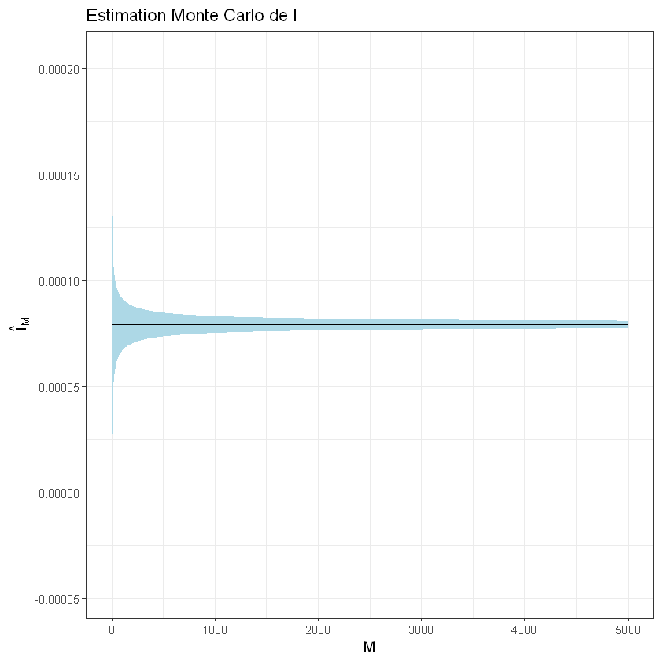

```r
set.seed(123) #Onfixe le germe pour avoir le même résultat

#Dans la suit M est l'effort de Monte Carlo, mu la moyenne mu, j et r sont définit comme dans le TD
S_tau=function(M,mu,j,r)#On créée la fonction S_tau
{
  S_tau=1:M
  for (i in 1:M)
  {
    S=0
    while (S>r & S<j)
    {
      X=rnorm(n=1,mean=mu,sd=1)
      S=S+X
    }
    S_tau[i]=S
  }
  return(S_tau)
}

IS=function(M,mu,j,r)#Voici notre fonction estimateur
{
  S=S_tau(M,mu,j,r)
  IS=mean(S*indicatrice(S,j)*exp(-2*mu*S))
  return(IS)
}

IS(10000,1,5,-50)#7.7e-05

### On affiche finalement l'intervalle de confiance à 95 %
library(ggplot2)
library(dplyr)

#Calcul de la variance
S=S_tau(10000,1,5,-50)
gamma2_hat <- var(S*indicatrice(S,5)*exp(-2*1*S)) # Variance de Monte Carlo de la proba

z_975 <- qnorm(0.975, 0, 1) # Quantile à 0.975 de la loi normale centrée réduite

my_samples = tibble(index = 1:5000, sample = IS(5000,1,5,-50))
my_samples %>%
  mutate(Estimate = cumsum(sample) / index,
         IC_95_inf = Estimate - z_975 * sqrt(gamma2_hat / index),
         IC_95_sup = Estimate + z_975 * sqrt(gamma2_hat / index)) %>%
  ggplot(aes(x = index)) +
  geom_ribbon(aes(ymin = IC_95_inf, ymax = IC_95_sup),
              fill = "lightblue") +
  geom_line(aes(y = Estimate)) +
  labs(x = "M", title = "Estimation Monte Carlo de I",
       y = expression(hat(I)[M])) +
  theme_bw()

#Regardons si il y a bien une diminution de la variance.
gamma2_hat
```

Nous avons donc réussi à réduire la variance de l'estimateur de Monte - Carlo.

## Remerciements

Ce problème nous a été donné par Mr Pierre Gloaguen à l'ENSTA Paris : https://papayoun.github.io/courses/2020_monte_carlo/ .